# Predicting Heart Disease

Spring 2026 Data Science Project

### Team Members

| Name | Contribution | Summary |
| --- | --- | --- |
| Tegan Hakim | A, B, C, D, E | Proposed initial idea, gathered + preprocessed + analyzed the heart disease dataset, helped with model bulding and development |
| Steven Lewis | C, D, E, F, G | Built and trained the predictive models based on prior insights from the analysis, assisted with final documentation |
| Tyler Cronk | B, F, G, H | Assisted in preprocessing data, created visualizations for interpretation in the analysis and conclusions section |
| Joshua Thangaraj | D, E, F, G | Assisted in ML development, visualization of outputs, interpretation of results, and curated the final project |
| Andrew Benevento | B, C, E, G | Assisted in dataset curation and EDA with analysis of summary statistics, ML training/tuning, and final documentation |

# Introduction

Heart disease is a **leading cause of death worldwide**, and early detection can significantly improve patient outcomes (Gruson et al., 2025). In this project, we aim to develop a predictive model that can identify individuals at risk of heart disease based on various health indicators. We will utilize a dataset containing patient information such as age, sex, BMI, presence of smoking/drinking, diabetes, and other relevant features to train our model. By analyzing this data, we hope to uncover patterns and insights that can aid in the early diagnosis of heart disease. We aim to identify the most significant risk factors correlated with heart disease and build a model that can predict the likelihood of heart disease in patients based on these factors.

> Gruson, D., Peranio, C., Štaraitė, A., Hobbs, R., Borch-Johnsen, K., Ademi, Z., Uchmanowicz, I., & Jonhson, N. (2025). Highlights from the Manifesto on Early Detection and Diagnosis of Cardiovascular Disease: The Role of Laboratory Tests and Emerging Technologies. EJIFCC, 36(1), 9–11. https://pmc.ncbi.nlm.nih.gov/articles/PMC11886626/

# Data Curation

The following dataset was used for this project. It contains various health indicators and demographic information about individuals, which we will use to predict the likelihood of heart disease. Taken from Kaggle, the dataset was curated from the 2020 CDC Behavioral Risk Factor Surveillance System (BRFSS) Survey, which collects data on health-related risk behaviors, chronic health conditions, and use of preventive services among U.S. residents.

**Name:** Indicators of Heart Disease (2022 UPDATE)  
**Source:** [Kaggle Dataset Link](https://www.kaggle.com/datasets/kamilpytlak/personal-key-indicators-of-heart-disease/data)  
**Size:** 319,795 rows (entries) x 18 columns (attributes)

> This Kaggle dataset was curated from the 2020 CDC Behavioral Risk Factor Surveillance System (BRFSS) Survey.  
> Original CDC data: [CDC BRFSS 2020](https://www.cdc.gov/brfss/annual_data/annual_2020.html)

Note: This dataset contains data for 2020 and 2022, however, we are only using 2020 data as the 2022 dataset only contains data on positive cases of heart disease, which would make the model unable to discern whether or not a person has heart disease.

### Data Curation Process

The data curation process involves several steps:

1. Loading the dataset and inspecting its structure
2. Check for missing values
3. Parsing and cleaning the dataset

Before we begin, lets import all necessary libraries and configure settings.

```python
########################
### Import libraries ###
########################

from sklearn.metrics import classification_report, confusion_matrix, ConfusionMatrixDisplay
from sklearn.model_selection import train_test_split, StratifiedKFold
from sklearn.metrics import f1_score, recall_score, precision_score
from sklearn.linear_model import LogisticRegression
from sklearn.ensemble import RandomForestClassifier
from sklearn.model_selection import GridSearchCV
from sklearn.preprocessing import StandardScaler
from matplotlib.patches import Patch
import matplotlib.pyplot as plt
from scipy import stats
import seaborn as sns
import pandas as pd
import numpy as np

# Warnings and display settings
import warnings
warnings.filterwarnings('ignore')
plt.style.use('seaborn-v0_8-whitegrid')
sns.set_palette("colorblind")
plt.style.use('seaborn-v0_8-whitegrid')
plt.rcParams['figure.figsize'] = (12, 6)
```

### 1) Loading the dataset and inspecting its structure

First, we load the dataset using Pandas and inspect its structure to determine the number of features/samples.

```python
####################
### Read dataset ###
####################

# Load the dataset
file_path = 'data/heart_2020_cleaned.csv'
df = pd.read_csv(file_path)

# Print out dataset info
print(f"Dataset Shape: {df.shape}")
print(f"Number of Features: {df.shape[1]}")
print(f"Number of Samples: {df.shape[0]}")
print("Head of Dataset:")
display(df.head())
```

```
Dataset Shape: (319795, 18)
Number of Features: 18
Number of Samples: 319795
Head of Dataset:
```

|  | HeartDisease | BMI | Smoking | AlcoholDrinking | Stroke | PhysicalHealth | MentalHealth | DiffWalking | Sex | AgeCategory | Race | Diabetic | PhysicalActivity | GenHealth | SleepTime | Asthma | KidneyDisease | SkinCancer |
| --- | --- | --- | --- | --- | --- | --- | --- | --- | --- | --- | --- | --- | --- | --- | --- | --- | --- | --- |
| 0 | No | 16.60 | Yes | No | No | 3.0 | 30.0 | No | Female | 55-59 | White | Yes | Yes | Very good | 5.0 | Yes | No | Yes |
| 1 | No | 20.34 | No | No | Yes | 0.0 | 0.0 | No | Female | 80 or older | White | No | Yes | Very good | 7.0 | No | No | No |
| 2 | No | 26.58 | Yes | No | No | 20.0 | 30.0 | No | Male | 65-69 | White | Yes | Yes | Fair | 8.0 | Yes | No | No |
| 3 | No | 24.21 | No | No | No | 0.0 | 0.0 | No | Female | 75-79 | White | No | No | Good | 6.0 | No | No | Yes |
| 4 | No | 23.71 | No | No | No | 28.0 | 0.0 | Yes | Female | 40-44 | White | No | Yes | Very good | 8.0 | No | No | No |

This dataset contains **319,795 rows (entries) and 18 columns (features)**, which means we have a large number of samples to work with. The columns represent various health indicators and demographic information about the individuals in the dataset. After printing out the first 5 lines of the dataset, we can see that there are 10 columns that contain binary (Yes/No) values, 4 numeric columns, and 4 categorical columns. The target variable is `HeartDisease`, which determines whether someone has been diagnosed with heart disease (Yes) or not (No).

### 2) Check for missing values

Next, we will check for missing values in the dataset to determine if we need to perform any imputation or data cleaning before proceeding with our analysis and model building.

```python
##########################################
### Check datatypes and missing values ###
##########################################

print(f"Data types:\n{df.dtypes.value_counts()}")
print(f"\nMissing values summary: {df.isnull().sum().sum()} total missing values")
```

```
Data types:
str        14
float64     4
Name: count, dtype: int64

Missing values summary: 0 total missing values
```

We determined that there are **no missing values** in the dataset, which means no further steps are required.

### 3) Parse + Clean Dataset

Lastly, we will increase readability and interpretability of the dataset by parsing and cleaning the data. We ensured that all strictly Yes/No categorical variables were properly encoded as 1s and 0s. We also renamed some categories for clarity, such as changing "80 or older" to "80+" in the `AgeCategory` feature. The rest of the categorical features are left to be handled by one-hot encoding or ordinal encoding as needed during the model development phase. After these cleaning steps, the dataset is ready for EDA.

```python
###############################
### Parse and clean dataset ###
###############################

# Replace '80 or older' with '80+' for better readability
df['AgeCategory'] = df['AgeCategory'].replace('80 or older', '80+')
# Convert binary string columns to numeric (1 for 'Yes', 0 for 'No')
binary_str_cols = ['HeartDisease', 'Smoking', 'AlcoholDrinking', 'Stroke',
               'DiffWalking', 'Diabetic', 'PhysicalActivity', 'Asthma',
               'KidneyDisease', 'SkinCancer']
for col in binary_str_cols:
    df[col] = df[col].map(lambda x: 1 if x == "Yes" else 0)
# Display updated df
display(df.head())
```

|  | HeartDisease | BMI | Smoking | AlcoholDrinking | Stroke | PhysicalHealth | MentalHealth | DiffWalking | Sex | AgeCategory | Race | Diabetic | PhysicalActivity | GenHealth | SleepTime | Asthma | KidneyDisease | SkinCancer |
| --- | --- | --- | --- | --- | --- | --- | --- | --- | --- | --- | --- | --- | --- | --- | --- | --- | --- | --- |
| 0 | 0 | 16.60 | 1 | 0 | 0 | 3.0 | 30.0 | 0 | Female | 55-59 | White | 1 | 1 | Very good | 5.0 | 1 | 0 | 1 |
| 1 | 0 | 20.34 | 0 | 0 | 1 | 0.0 | 0.0 | 0 | Female | 80+ | White | 0 | 1 | Very good | 7.0 | 0 | 0 | 0 |
| 2 | 0 | 26.58 | 1 | 0 | 0 | 20.0 | 30.0 | 0 | Male | 65-69 | White | 1 | 1 | Fair | 8.0 | 1 | 0 | 0 |
| 3 | 0 | 24.21 | 0 | 0 | 0 | 0.0 | 0.0 | 0 | Female | 75-79 | White | 0 | 0 | Good | 6.0 | 0 | 0 | 1 |
| 4 | 0 | 23.71 | 0 | 0 | 0 | 28.0 | 0.0 | 1 | Female | 40-44 | White | 0 | 1 | Very good | 8.0 | 0 | 0 | 0 |

# Exploratory Data Analysis

For our exploratory data analysis, we will:

1. Look at summary statistics of the dataset to understand the distribution of the features and identify any potential outliers
2. Visualize the relationships between some features and the target variable (`HeartDisease`) using various plots
3. Create a correlation heatmap to identify which features are most strongly correlated with one another
4. Analyze the class balance of the target variable to determine if we need to apply any techniques to address class imbalance during model training.

### 1) Summary Statistics

Let's analyze the summary statistics of the dataset.

```python
##########################
### Summary statistics ###
##########################

df.describe(include='all')
```

|  | HeartDisease | BMI | Smoking | AlcoholDrinking | Stroke | PhysicalHealth | MentalHealth | DiffWalking | Sex | AgeCategory | Race | Diabetic | PhysicalActivity | GenHealth | SleepTime | Asthma | KidneyDisease | SkinCancer |
| --- | --- | --- | --- | --- | --- | --- | --- | --- | --- | --- | --- | --- | --- | --- | --- | --- | --- | --- |
| count | 319795.000000 | 319795.000000 | 319795.000000 | 319795.000000 | 319795.000000 | 319795.00000 | 319795.000000 | 319795.000000 | 319795 | 319795 | 319795 | 319795.000000 | 319795.000000 | 319795 | 319795.000000 | 319795.000000 | 319795.000000 | 319795.000000 |
| unique | NaN | NaN | NaN | NaN | NaN | NaN | NaN | NaN | 2 | 13 | 6 | NaN | NaN | 5 | NaN | NaN | NaN | NaN |
| top | NaN | NaN | NaN | NaN | NaN | NaN | NaN | NaN | Female | 65-69 | White | NaN | NaN | Very good | NaN | NaN | NaN | NaN |
| freq | NaN | NaN | NaN | NaN | NaN | NaN | NaN | NaN | 167805 | 34151 | 245212 | NaN | NaN | 113858 | NaN | NaN | NaN | NaN |
| mean | 0.085595 | 28.325399 | 0.412477 | 0.068097 | 0.037740 | 3.37171 | 3.898366 | 0.138870 | NaN | NaN | NaN | 0.127588 | 0.775362 | NaN | 7.097075 | 0.134061 | 0.036833 | 0.093244 |
| std | 0.279766 | 6.356100 | 0.492281 | 0.251912 | 0.190567 | 7.95085 | 7.955235 | 0.345812 | NaN | NaN | NaN | 0.333631 | 0.417344 | NaN | 1.436007 | 0.340718 | 0.188352 | 0.290775 |
| min | 0.000000 | 12.020000 | 0.000000 | 0.000000 | 0.000000 | 0.00000 | 0.000000 | 0.000000 | NaN | NaN | NaN | 0.000000 | 0.000000 | NaN | 1.000000 | 0.000000 | 0.000000 | 0.000000 |
| 25% | 0.000000 | 24.030000 | 0.000000 | 0.000000 | 0.000000 | 0.00000 | 0.000000 | 0.000000 | NaN | NaN | NaN | 0.000000 | 1.000000 | NaN | 6.000000 | 0.000000 | 0.000000 | 0.000000 |
| 50% | 0.000000 | 27.340000 | 0.000000 | 0.000000 | 0.000000 | 0.00000 | 0.000000 | 0.000000 | NaN | NaN | NaN | 0.000000 | 1.000000 | NaN | 7.000000 | 0.000000 | 0.000000 | 0.000000 |
| 75% | 0.000000 | 31.420000 | 1.000000 | 0.000000 | 0.000000 | 2.00000 | 3.000000 | 0.000000 | NaN | NaN | NaN | 0.000000 | 1.000000 | NaN | 8.000000 | 0.000000 | 0.000000 | 0.000000 |
| max | 1.000000 | 94.850000 | 1.000000 | 1.000000 | 1.000000 | 30.00000 | 30.000000 | 1.000000 | NaN | NaN | NaN | 1.000000 | 1.000000 | NaN | 24.000000 | 1.000000 | 1.000000 | 1.000000 |

We can draw a few insights from the summary statistics:

- Numeric features have very different scales. `BMI` ranges from about 12-95, `SleepTime` from 1-24, and `PhysicalHealth/MentalHealth` from 0-30. Most binary features are constrained to 0 or 1. This difference in scale matters for models like Logistic Regression, where a feature with a high range can dominate one with a smaller range simply due to magnitude. We address this later by applying `StandardScaler` before training, which centers each numeric feature to a mean of 0 and variance of 1. However, models like Random Forest are scale-invariant and do not require this step.
- Some values look unusual but are valid. The maximum `SleepTime` of 24 hours is technically possible (for example a patient recovering from illness) and is present in the original CDC BRFSS survey data. Rather than treating these unusual data points as errors, we retain them as although rare cases, they may be informative.
- **Female** is the most common sex (167,805), **65-69** is the most common age group (34,151), **White** is the most represented race (245,212), and **Very good** is the most self-reported health status (113,858). These differences are worth noting as the dataset is not uniformly distributed across demographic data and may affect how well the model generalizes to underrepresented groups.
- The target variable (`HeartDisease`) is heavily right skewed. With a mean of 0.086, only about 8.6% of respondents reported having heart disease. We must do something about this class imbalance during model training, such as using class weights and stratified KFold sampling to ensure the model learns from both classes effectively.

### 2) Visualize Relationships Between Features and Target Variable

Now we will visualize and analyze a few relationships between features. We will compare:

1. **Age and Heart Disease** using a **Chi-Squared** test to determine importance, and visualizing population statistics using a **Grouped Bar Chart**.
2. **Smoking, Drinking and Heart Disease** using an **ANOVA** test and a **Tukey HSD** post-hoc test, visualizing population statistics using a **Grouped Bar Chart**
3. **Sex and Heart Disease** using a **Chi-Squared** test, visualizing the population with two **Pie-Charts**

#### 2.1) Age and Heart disease

Lets run a chi-squared test to see if there is a significant association between age category and heart disease diagnosis. We will create a contingency table of counts for each age category against the presence or absence of heart disease, then apply the chi-squared test to determine if the observed distribution differs significantly from what we would expect by chance.

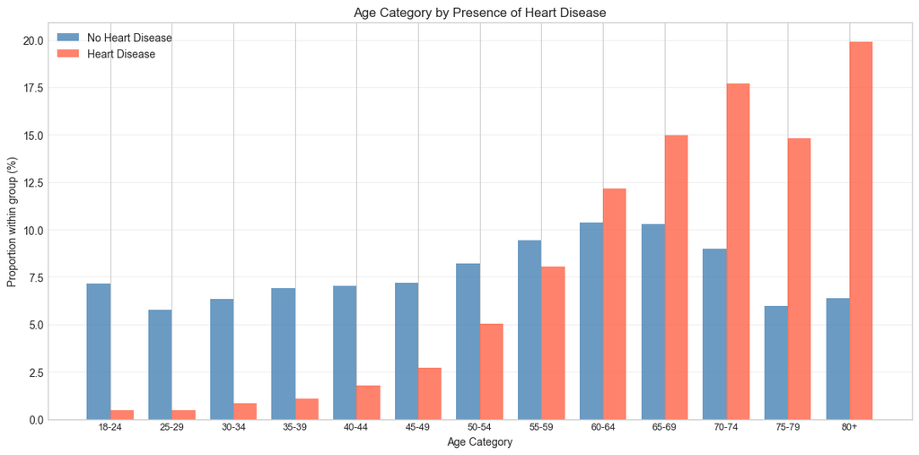

```python
###################################################
### Visualize age distribution of heart disease ###
###################################################

# Calculate proportions of each age category within heart disease and no heart disease groups
age_order = ['18-24','25-29','30-34','35-39','40-44','45-49',
             '50-54','55-59','60-64','65-69','70-74','75-79','80+']
true_counts  = df[df['HeartDisease'] == 1]['AgeCategory'].value_counts(normalize=True).reindex(age_order) * 100
false_counts  = df[df['HeartDisease'] == 0]['AgeCategory'].value_counts(normalize=True).reindex(age_order) * 100

# Create side-by-side bar chart
x = np.arange(len(age_order))
width = 0.38
fig, ax = plt.subplots()
ax.bar(x - width/2, false_counts, width, label='No Heart Disease', color='steelblue', alpha=0.8)
ax.bar(x + width/2, true_counts, width, label='Heart Disease', color='tomato', alpha=0.8)

# Update axes and labels
ax.set_xticks(x)
ax.set_xticklabels(age_order, fontsize=9)
ax.set_xlabel('Age Category')
ax.set_ylabel('Proportion within group (%)')
ax.set_title('Age Category by Presence of Heart Disease')
ax.legend()
ax.grid(axis='y', linewidth=0.5, alpha=0.5)
ax.set_axisbelow(True)
plt.tight_layout()
plt.show()
```

```python
# Chi-squared test for association between age category and heart disease
contingency = pd.crosstab(df['HeartDisease'], df['AgeCategory'])
res = stats.chi2_contingency(contingency)
# Print test statistic and p-value
print(f"Test Statistic: {res.statistic}")
print(f"p-value: {res.pvalue}")
```

```
Test Statistic: 19299.92039113256
p-value: 0.0
```

**Statistical Test**: Chi-squared test

**Null Hypothesis (H<sub>0</sub>)**: There is no association between age category and heart disease.

**Alternative Hypothesis (H<sub>a</sub>)**: There is an association between age category and heart disease.

Since the p-value of the Chi-squared test is less than 0.05, we **reject the null hypothesis** and conclude that there is a statistically significant association between age category and heart disease. As seen in the grouped bar chart, the proportion of individuals with heart disease increases with age, suggesting that older age categories (specifically 60 and above) are more likely to have heart disease compared to younger age categories.

#### 2.2) Smoking, Drinking, and Heart Disease

Lets run a ANOVA test with a Tukey HSD post-hoc test to see if there are significant differences in heart disease rates among the three groups: those who smoke and drink, those who only smoke, and those who only drink. We will compare the mean heart disease rates across these groups to determine if smoking and drinking together is associated with a higher risk of heart disease compared to either behavior alone, or none.

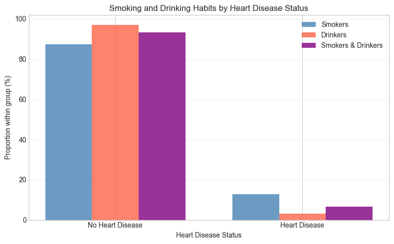

```python
#######################################################################
### Visualize smoking and drinking habits of heart disease patients ###
#######################################################################

# Calculate proportions of smokers, drinkers, and both within heart disease and no heart disease groups
smoker_counts  = df[(df['Smoking'] == 1) & (df['AlcoholDrinking'] == 0)]['HeartDisease'].value_counts(normalize=True) * 100
drinker_counts  = df[(df['Smoking'] == 0) & (df['AlcoholDrinking'] == 1)]['HeartDisease'].value_counts(normalize=True) * 100
both_counts  = df[(df['Smoking'] == 1) & (df['AlcoholDrinking'] == 1)]['HeartDisease'].value_counts(normalize=True) * 100
labels = ['No Heart Disease', 'Heart Disease']

# Create side-by-side bar chart
x = np.arange(len(labels))
width = 0.25
fig, ax = plt.subplots(figsize=(8, 5))
ax.bar(x - width, smoker_counts, width, label='Smokers', color='steelblue', alpha=0.8)
ax.bar(x, drinker_counts, width, label='Drinkers', color='tomato', alpha=0.8)
ax.bar(x + width, both_counts, width, label='Smokers & Drinkers', color='purple', alpha=0.8)

# Update axes and labels
ax.set_xticks(x)
ax.set_xticklabels(labels)
ax.set_xlabel('Heart Disease Status')
ax.set_ylabel('Proportion within group (%)')
ax.set_title('Smoking and Drinking Habits by Heart Disease Status')
ax.legend()
ax.grid(axis='y', linewidth=0.5, alpha=0.5)
ax.set_axisbelow(True)
plt.tight_layout()
plt.show()
```

```python
# ANOVA test for association between smoking/drinking habits and heart disease
smoker_group = df[(df['Smoking'] == 1) & (df['AlcoholDrinking'] == 0)]['HeartDisease']
drinker_group = df[(df['Smoking'] == 0) & (df['AlcoholDrinking'] == 1)]['HeartDisease']
both_group = df[(df['Smoking'] == 1) & (df['AlcoholDrinking'] == 1)]['HeartDisease']
f_stat, p_value = stats.f_oneway(smoker_group, drinker_group, both_group)
# Print test statistic and p-value
print(f"F-statistic: {f_stat}")
print(f"p-value: {p_value}")

# Post Hoc Tukey's HSD test
tukey = stats.tukey_hsd(smoker_group, drinker_group, both_group)
print("\nTukey HSD Post Hoc Test Results:")
print(tukey.pvalue)
```

```
F-statistic: 547.3207796073817
p-value: 1.6761217111020712e-237

Tukey HSD Post Hoc Test Results:
[[1.00000000e+00 0.00000000e+00 0.00000000e+00]
 [0.00000000e+00 1.00000000e+00 9.99200722e-16]
 [0.00000000e+00 9.99200722e-16 1.00000000e+00]]
```

**Statistical Test**: ANOVA test + Tukey HSD Post Hoc Test

**Null Hypothesis (H<sub>0</sub>)**: There is no effect of smoking and drinking status on heart disease prevalence.

**Alternative Hypothesis (H<sub>a</sub>)**: There is an effect of smoking and drinking status on heart disease prevalence.

Since the p-value of the ANOVA test is well below 0.05, we **reject the null hypothesis** and conclude that there is a statistically significant difference in heart disease prevalence among individuals who only smoke, only drink, or do both. After running a Tukey HSD Post Hoc Test, we can identify which specific groups differ significantly from each other (all pairwise comparisons are significant). Therefore, each group (smoking, drinking, or both) has a distinct heart disease rate. As seen in the bar chart, those who only smoke have a higher prevalence of heart disease compared to those who only drink. This suggests that smoking may have a stronger association with heart disease than drinking. Since both smoking and alcohol drinking affect heart disease prevalance, it is interesting that the combination of both is not significantly higher than just smoking alone.

#### 2.3) Sex and Heart Disease

Lets run a chi-squared test to see if there is a significant association between sex and heart disease diagnosis. We will create a contingency table of counts for each sex against the presence or absence of heart disease, then apply the chi-squared test to determine if the observed distribution differs significantly from what we would expect by chance.

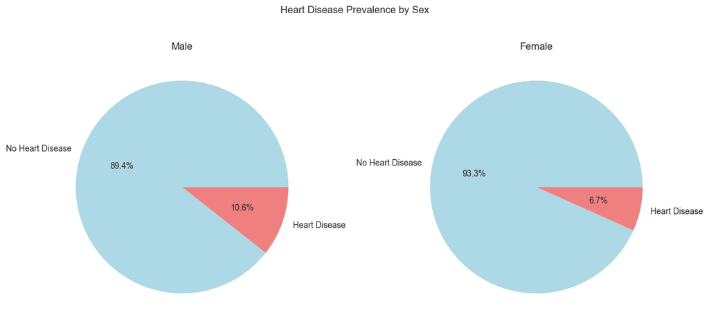

```python
################################################
### Visualize impact of sex on heart disease ###
################################################

# Calculate proportions of heart disease
male_counts = df[df["Sex"] == "Male"]["HeartDisease"].value_counts(normalize=True) * 100
female_counts = df[df["Sex"] == "Female"]["HeartDisease"].value_counts(normalize=True) * 100

# Create side-by-side pie charts
fig, axes = plt.subplots(1, 2)
axes[0].pie(male_counts, labels=['No Heart Disease', 'Heart Disease'], autopct='%1.1f%%', colors=['lightblue', 'lightcoral'])
axes[1].pie(female_counts, labels=['No Heart Disease', 'Heart Disease'], autopct='%1.1f%%', colors=['lightblue', 'lightcoral'])

# Update titles and layout
axes[0].set_title('Male')
axes[1].set_title('Female')
plt.suptitle('Heart Disease Prevalence by Sex')
plt.tight_layout()
plt.show()
```

```python
# Chi square test for association between sex and heart disease
contingency = pd.crosstab(df['HeartDisease'], df['Sex'])
res = stats.chi2_contingency(contingency)
# Print test statistic and p-value
print(f"Test Statistic: {res.statistic}")
print(f"p-value: {res.pvalue}")
```

```
Test Statistic: 1568.3069168517372
p-value: 0.0
```

**Statistical Test**: Chi-squared test

**Null Hypothesis (H<sub>0</sub>)**: There is no association between sex and heart disease.

**Alternative Hypothesis (H<sub>a</sub>)**: There is an association between sex and heart disease.

Since the p-value of the Chi-squared test is less than 0.05, we **reject the null hypothesis** and conclude that there is a statistically significant association between sex and heart disease. As seen in the pie charts, the proportion of individuals with heart disease differs between males and females.

### 3) Checking for correlation between features

Finally, we will create a correlation heatmap to visualize the pairwise correlations between all numeric features in the dataset.

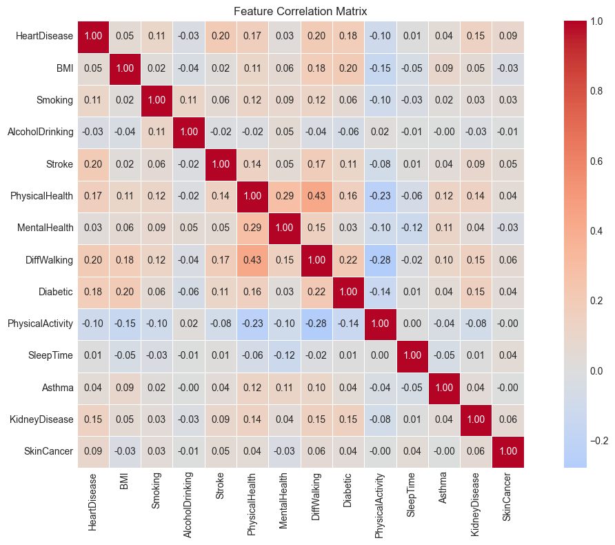

```python
#################################################################################
### Use Pearson correlation for numeric features and visualize with a heatmap ###
#################################################################################

# Select only numeric columns for correlation analysis
numeric_cols = df.select_dtypes(include='number')
corr = numeric_cols.corr()
# Create a heatmap to visualize the correlation matrix
plt.figure(figsize=(12, 8))
sns.heatmap(corr, annot=True, fmt='.2f', cmap='coolwarm', center=0, linewidths=0.5, square=True)
plt.title('Feature Correlation Matrix')
plt.tight_layout()
plt.show()
```

It seems as though there are some slight correlations between features but most are relatively weak showing that most features are independent of one another. The most significant correlation was between `PhysicalHealth` and `DiffWalking` with a value of 0.43. This suggests that these features may be somewhat related which makes sense as they both relate to physical well-being. However, there are no extremely high correlations that would indicate any conflicting issues. This suggests that these features provide unique information for predicting heart disease.

### 4) Analyzing Class Balance of Target Variable

Finally, we will analyze the class balance of the target variable (**HeartDisease**) to determine if we need to apply any techniques to address class imbalance during model training.

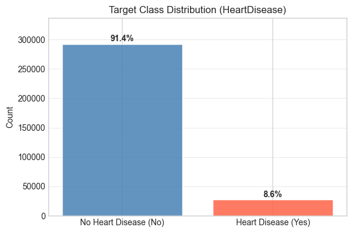

```
Ratio (no heart disease:heart disease) ~ 10:1
```

```python
# Calculate class distribution for target variable
counts = df['HeartDisease'].value_counts()
pct = df['HeartDisease'].value_counts(normalize=True) * 100

# Visualize class imbalance with a bar chart
fig, ax = plt.subplots(figsize=(6, 4))
bars = ax.bar(['No Heart Disease (No)', 'Heart Disease (Yes)'], counts.values, color=['steelblue', 'tomato'], alpha=0.85, edgecolor='white')
for bar, p in zip(bars, pct.values):
    ax.text(bar.get_x() + bar.get_width()/2, bar.get_height() + 1500, f'{p:.1f}%', ha='center', va='bottom', fontweight='bold')

# Update axes and labels
ax.set_title('Target Class Distribution (HeartDisease)')
ax.set_ylabel('Count')
ax.set_ylim(0, counts.max() * 1.15)
ax.grid(axis='y', linewidth=0.5, alpha=0.6)
plt.tight_layout()
plt.show()

# Print class imbalance ratio
print(f"Ratio (no heart disease:heart disease) ~ {counts[0]//counts[1]}:1")
```

**What is class imbalance and why do we care about it?**

The chart above reveals a significant imbalance. About **91% of datapoints have no heart disease**, while only about **9% do**. This creates a serious problem for classifiers as models that simply predict "No Heart Disease" for every single patient would achieve about 91% accuracy while being completely useless at detecting actual heart disease cases. This matters especially in medical contexts where the cost of a **false negative** (missing a real case of heart disease) is far higher than a **false positive** (detecting a case that doesn't exist). We care more about **recall**.

# Primary Analysis

Based on our exploratory data analysis, we identified that age, smoking status, and sex are all significantly associated with heart disease. Our task is now to build a model that can **predict whether an individual has heart disease** given these features. Since the target variable `HeartDisease` is binary (0 = No, 1 = Yes), this is a **binary classification problem**.

1. Preprocess and encode all features for machine learning
2. Address **class imbalance**, which is a critical issue in medical datasets
3. Prepare a train/test split of the data for model training and evaluation
4. Build and train a **Random Forest Classifier** model
5. Build and train a **Logistic Regression** model

In the next section, we will analyze and compare the performance of both models and select the best one based on evaluation metrics to be our final predictive model for heart disease.

### Step 1: Feature Encoding

Before training any model, we need to encode categorical features into numeric form. We have three types of categorical features:

- **Binary string columns**: already encoded in data curation (e.g., `Smoking`, `Stroke`)
- **Ordinal column**: `AgeCategory` (has a implicit order from youngest to oldest)
- **Nominal columns**: `Race`, `Sex`, and `GenHealth` (no natural order so we one-hot encode them)

```python
# Ordinal Encoding (maintain natural order)
age_order = ['18-24','25-29','30-34','35-39','40-44','45-49',
             '50-54','55-59','60-64','65-69','70-74','75-79','80+']
df['AgeCategoryEncoded'] = df['AgeCategory'].map({v: i for i, v in enumerate(age_order)})

# One Hot Encoding (no order)
df_encoded = pd.get_dummies(df, columns=['Sex', 'Race', 'GenHealth'], drop_first=True)

# Drop original AgeCategory column since we have the encoded version now
df_encoded = df_encoded.drop(columns=['AgeCategory'])

# Define features (X) and target (y)
X = df_encoded.drop(columns=['HeartDisease'])
y = df_encoded['HeartDisease']

# Print shape, target distribution, and final feature list
print(f"Feature matrix shape: {X.shape}")
print(f"Target distribution:\n{y.value_counts(normalize=True).mul(100).round(2)}")
print(f"\nFeatures:", X.columns)
```

```
Feature matrix shape: (319795, 24)
Target distribution:
HeartDisease
0    91.44
1     8.56
Name: proportion, dtype: float64

Features: Index(['BMI', 'Smoking', 'AlcoholDrinking', 'Stroke', 'PhysicalHealth',
       'MentalHealth', 'DiffWalking', 'Diabetic', 'PhysicalActivity',
       'SleepTime', 'Asthma', 'KidneyDisease', 'SkinCancer',
       'AgeCategoryEncoded', 'Sex_Male', 'Race_Asian', 'Race_Black',
       'Race_Hispanic', 'Race_Other', 'Race_White', 'GenHealth_Fair',
       'GenHealth_Good', 'GenHealth_Poor', 'GenHealth_Very good'],
      dtype='str')
```

### Step 2: Addressing Class Imbalance

A critical concern in medical classification tasks is **class imbalance**. As seen during EDA, the target variable is significantly imbalanced. Both our **Random Forest** and **Logistic Regression** models support a parameter called `class_weight='balanced'`. When set, it will automatically adjust the weight each class receives during training. We will also use stratified K-Fold sampling during cross-validation to ensure that each fold maintains the same class distribution as the overall dataset, which helps the model learn from both classes effectively.

### Step 3: Train/Test Split for Model Training

We split the data **80/20** for training/testing using stratified sampling. Stratification ensures that both the training and test sets maintain the same approximately 9% / 91% class ratio as the full dataset. This is crucial when dealing with imbalanced classes.

```python
# Stratified 80/20 train/test split
X_train, X_test, y_train, y_test = train_test_split(
    X, y,
    test_size=0.20,
    random_state=42,
    stratify=y
)

print(f"Training set: {X_train.shape[0]:,} rows")
print(f"Test set: {X_test.shape[0]:,} rows")
print(f"\nTraining class balance:\n{y_train.value_counts(normalize=True).mul(100).round(2)}")
print(f"\nTest class balance:\n{y_test.value_counts(normalize=True).mul(100).round(2)}")
```

```
Training set: 255,836 rows
Test set: 63,959 rows

Training class balance:
HeartDisease
0    91.44
1     8.56
Name: proportion, dtype: float64

Test class balance:
HeartDisease
0    91.44
1     8.56
Name: proportion, dtype: float64
```

### Step 4: Random Forest Classifier

Random Forest is an **ensemble learning** method that builds many decision trees during training and outputs the class that is the **majority vote** of individual trees. It is a strong first choice for this dataset for several reasons as it:

- **Handles mixed data types** which allows us to use both numeric and categorical features
- Is **robust to outliers** due to the ensemble nature of the model
- Has **built-in feature importance**, allowing us to identify which features are most influential in predicting heart disease
- Is **resistant to overfitting** due to bootstrap methods (bagging)

### Hyperparameter Tuning

Rather than accepting default parameters, we utilize GridSearchCV to tune the most impactful hyperparameters using **5-fold Stratified Cross-Validation**. We test combinations of:

- `n_estimators`: number of trees
- `max_depth`: how deep each tree can grow (limits overfitting)
- `min_samples_leaf`: minimum samples required at a leaf node

```python
####################################################################
# Random Forest Classifier Hyperparameter tuning with GridSearchCV #
####################################################################

# Define hyperparameter grid for Random Forest
param_grid = {
    'n_estimators':     [100, 200, 300],
    'max_depth':        [10, 20, None],
    'min_samples_leaf': [1, 5]
}
# Set up 5-fold stratified cross-validation
cv = StratifiedKFold(n_splits=5, shuffle=True, random_state=42)
# Initialize Random Forest
rf = RandomForestClassifier(
    class_weight='balanced',
    n_jobs=1,
    random_state=42
)
# Initialize GridSearchCV
grid_search = GridSearchCV(
    estimator=rf,
    param_grid=param_grid,
    cv=cv,
    scoring='recall',
    n_jobs=1,
    verbose=2,
    refit=True
)

# Calculate total combinations and fit GridSearchCV
grid_search.fit(X_train, y_train)
# Results
results_df = pd.DataFrame(grid_search.cv_results_)[['param_n_estimators', 'param_max_depth', 'param_min_samples_leaf', 'mean_test_score', 'std_test_score', 'rank_test_score']].sort_values('rank_test_score')
print("\nAll combinations (sorted by recall):")
display(results_df)
print(f"Best hyperparameters: {grid_search.best_params_}")
print(f"Best CV Recall: {grid_search.best_score_:.4f}\n")
```

```
Fitting 5 folds for each of 18 candidates, totalling 90 fits
[CV] END .max_depth=10, min_samples_leaf=1, n_estimators=100; total time=   9.5s
[CV] END .max_depth=10, min_samples_leaf=1, n_estimators=100; total time=   8.7s
[CV] END .max_depth=10, min_samples_leaf=1, n_estimators=100; total time=   8.4s
[CV] END .max_depth=10, min_samples_leaf=1, n_estimators=100; total time=   8.5s
[CV] END .max_depth=10, min_samples_leaf=1, n_estimators=100; total time=   8.5s
[CV] END .max_depth=10, min_samples_leaf=1, n_estimators=200; total time=  17.4s
[CV] END .max_depth=10, min_samples_leaf=1, n_estimators=200; total time=  16.9s
[CV] END .max_depth=10, min_samples_leaf=1, n_estimators=200; total time=  17.1s
[CV] END .max_depth=10, min_samples_leaf=1, n_estimators=200; total time=  17.1s
[CV] END .max_depth=10, min_samples_leaf=1, n_estimators=200; total time=  16.9s
[CV] END .max_depth=10, min_samples_leaf=1, n_estimators=300; total time=  25.4s
[CV] END .max_depth=10, min_samples_leaf=1, n_estimators=300; total time=  25.6s
[CV] END .max_depth=10, min_samples_leaf=1, n_estimators=300; total time=  26.1s
[CV] END .max_depth=10, min_samples_leaf=1, n_estimators=300; total time=  25.6s
[CV] END .max_depth=10, min_samples_leaf=1, n_estimators=300; total time=  26.6s
[CV] END .max_depth=10, min_samples_leaf=5, n_estimators=100; total time=   8.6s
[CV] END .max_depth=10, min_samples_leaf=5, n_estimators=100; total time=   8.6s
[CV] END .max_depth=10, min_samples_leaf=5, n_estimators=100; total time=   9.3s
[CV] END .max_depth=10, min_samples_leaf=5, n_estimators=100; total time=   9.9s
[CV] END .max_depth=10, min_samples_leaf=5, n_estimators=100; total time=   9.7s
[CV] END .max_depth=10, min_samples_leaf=5, n_estimators=200; total time=  20.6s
[CV] END .max_depth=10, min_samples_leaf=5, n_estimators=200; total time=  18.6s
[CV] END .max_depth=10, min_samples_leaf=5, n_estimators=200; total time=  18.7s
[CV] END .max_depth=10, min_samples_leaf=5, n_estimators=200; total time=  19.1s
[CV] END .max_depth=10, min_samples_leaf=5, n_estimators=200; total time=  19.0s
[CV] END .max_depth=10, min_samples_leaf=5, n_estimators=300; total time=  29.5s
[CV] END .max_depth=10, min_samples_leaf=5, n_estimators=300; total time=  26.6s
[CV] END .max_depth=10, min_samples_leaf=5, n_estimators=300; total time=  26.8s
[CV] END .max_depth=10, min_samples_leaf=5, n_estimators=300; total time=  28.3s
[CV] END .max_depth=10, min_samples_leaf=5, n_estimators=300; total time=  26.7s
[CV] END .max_depth=20, min_samples_leaf=1, n_estimators=100; total time=  15.0s
[CV] END .max_depth=20, min_samples_leaf=1, n_estimators=100; total time=  15.0s
[CV] END .max_depth=20, min_samples_leaf=1, n_estimators=100; total time=  15.2s
[CV] END .max_depth=20, min_samples_leaf=1, n_estimators=100; total time=  15.0s
[CV] END .max_depth=20, min_samples_leaf=1, n_estimators=100; total time=  15.3s
[CV] END .max_depth=20, min_samples_leaf=1, n_estimators=200; total time=  31.0s
[CV] END .max_depth=20, min_samples_leaf=1, n_estimators=200; total time=  29.8s
[CV] END .max_depth=20, min_samples_leaf=1, n_estimators=200; total time=  31.7s
[CV] END .max_depth=20, min_samples_leaf=1, n_estimators=200; total time=  28.7s
```

[output cut: 38 more lines]

```
[CV] END max_depth=None, min_samples_leaf=5, n_estimators=100; total time=  24.2s
[CV] END max_depth=None, min_samples_leaf=5, n_estimators=100; total time=  24.9s
[CV] END max_depth=None, min_samples_leaf=5, n_estimators=100; total time=  18.6s
[CV] END max_depth=None, min_samples_leaf=5, n_estimators=200; total time=  29.9s
[CV] END max_depth=None, min_samples_leaf=5, n_estimators=200; total time=  29.5s
[CV] END max_depth=None, min_samples_leaf=5, n_estimators=200; total time=  29.8s
[CV] END max_depth=None, min_samples_leaf=5, n_estimators=200; total time=  30.1s
[CV] END max_depth=None, min_samples_leaf=5, n_estimators=200; total time=  29.0s
[CV] END max_depth=None, min_samples_leaf=5, n_estimators=300; total time=  43.2s
[CV] END max_depth=None, min_samples_leaf=5, n_estimators=300; total time= 1.1min
[CV] END max_depth=None, min_samples_leaf=5, n_estimators=300; total time= 1.2min
[CV] END max_depth=None, min_samples_leaf=5, n_estimators=300; total time= 1.1min
[CV] END max_depth=None, min_samples_leaf=5, n_estimators=300; total time= 1.1min

All combinations (sorted by recall):
```

|  | param_n_estimators | param_max_depth | param_min_samples_leaf | mean_test_score | std_test_score | rank_test_score |
| --- | --- | --- | --- | --- | --- | --- |
| 4 | 200 | 10 | 5 | 0.797197 | 0.006628 | 1 |
| 3 | 100 | 10 | 5 | 0.796466 | 0.006323 | 2 |
| 5 | 300 | 10 | 5 | 0.796146 | 0.006222 | 3 |
| 1 | 200 | 10 | 1 | 0.791443 | 0.006595 | 4 |
| 2 | 300 | 10 | 1 | 0.790895 | 0.006744 | 5 |
| 0 | 100 | 10 | 1 | 0.789205 | 0.007953 | 6 |
| 10 | 200 | 20 | 5 | 0.664947 | 0.004045 | 7 |
| 11 | 300 | 20 | 5 | 0.664901 | 0.002799 | 8 |
| 9 | 100 | 20 | 5 | 0.663942 | 0.004521 | 9 |
| 17 | 300 | None | 5 | 0.617545 | 0.004294 | 10 |
| 16 | 200 | None | 5 | 0.616951 | 0.004390 | 11 |
| 15 | 100 | None | 5 | 0.616130 | 0.005822 | 12 |
| 6 | 100 | 20 | 1 | 0.366335 | 0.005365 | 13 |
| 8 | 300 | 20 | 1 | 0.365559 | 0.002779 | 14 |
| 7 | 200 | 20 | 1 | 0.364782 | 0.003969 | 15 |
| 14 | 300 | None | 1 | 0.105443 | 0.001972 | 16 |
| 12 | 100 | None | 1 | 0.104895 | 0.002696 | 17 |
| 13 | 200 | None | 1 | 0.104804 | 0.002397 | 18 |

```
Best hyperparameters: {'max_depth': 10, 'min_samples_leaf': 5, 'n_estimators': 200}
Best CV Recall: 0.7972
```

Our hyperparameter tuning process concluded that the best parameters for our **Random Forest** model are:

- `n_estimators`: 200
- `max_depth`: 10
- `min_samples_leaf`: 5

Now, lets examine the classification report from the tuned **Random Forest** model to evaluate its performance on the test set.

```python
# Look at the best estimator
rf_best = grid_search.best_estimator_

# Predictions
y_pred_rf = rf_best.predict(X_test)
y_prob_rf = rf_best.predict_proba(X_test)[:, 1]
rf_recall = recall_score(y_test, y_pred_rf, pos_label=1)

# Evaluate on test set
print("Random Forest: Testing Set Performance")
print(f"\nRecall Score: {rf_recall:.4f}")
print(f"\nClassification Report:")
print(classification_report(y_test, y_pred_rf, target_names=['No HD', 'Heart Disease']))
```

```
Random Forest: Testing Set Performance

Recall Score: 0.7920

Classification Report:
               precision    recall  f1-score   support

        No HD       0.97      0.73      0.84     58484
Heart Disease       0.22      0.79      0.34      5475

     accuracy                           0.74     63959
    macro avg       0.59      0.76      0.59     63959
 weighted avg       0.91      0.74      0.79     63959
```

With a recall of **0.79**, the **Random Forest** model is able to correctly identify **79%** of actual heart disease cases in the test set. This is a strong result given the class imbalance and suggests that the model is effectively learning patterns associated with heart disease. However, the precision is only **0.22**, meaning when the model predicts heart disease, it is correct only **22%** of the time. This indicates that the model produces a significant number of false positives. In medical contexts, this may be acceptable as we prioritize catching true cases, but it also means that many patients may be flagged for further testing unnecessarily. Overall, the **Random Forest** model shows decent performance. Lets try a **Logistic Regression** model to see if that can improve our results.

### Step 5: Logistic Regression

Logistic Regression is the standard **linear baseline** for binary classification. It sets the minimum performance requirement for models. Logistic regression is often used in [classification problems](https://doi.org/10.36416/1806-3756/e20220439) (Castro et al., 2022), including identifying and predicting disease. It is a strong alternative choice for this dataset for several reasons as it:

- Is **highly interpretable** since each coefficient directly tells you the direction and magnitude of a feature's effect on heart disease probability
- Is **fast to train**, making it practical even on thousands of rows
- Works well with **linear data**, which as discussed before age is linear, and a few other features may be as well

### Hyperparameter Tuning

Rather than accepting default parameters, we utilize GridSearchCV to tune the most impactful hyperparameters using **5-fold Stratified Cross-Validation**. We test combinations of:

- `C`: regularization strength
- `penalty`: type of regularization
- `solver`: algorithm to use for optimization

> Castro, Horacio Matias, and Juliana Carvalho Ferreira. “Linear and Logistic Regression Models: When to Use and How to Interpret Them?” Jornal Brasileiro de Pneumologia, vol. 48, no. 6, 24 Nov. 2022, p. e20220439, https://doi.org/10.36416/1806-3756/e20220439.

```python
###############################################################
# Logistic Regression Hyperparameter tuning with GridSearchCV #
###############################################################

# Scale features for logistic regression
scaler = StandardScaler()
X_train_s = scaler.fit_transform(X_train)
X_test_s  = scaler.transform(X_test)

# Define hyperparameter grid for Logistic Regression
param_grid_lr = [
    {'C': [0.01, 0.1, 1, 10], 'penalty': ['l2'], 'solver': ['lbfgs', 'liblinear']},
    {'C': [0.01, 0.1, 1, 10], 'penalty': ['l1'], 'solver': ['liblinear']}
]

# Set up 5-fold stratified cross-validation
cv = StratifiedKFold(n_splits=5, shuffle=True, random_state=42)
# Initialize Logistic Regression
lr = LogisticRegression(
    class_weight='balanced',
    max_iter=1000,
    random_state=42
)
# Initialize GridSearchCV
lr_grid_search = GridSearchCV(
    estimator=lr,
    param_grid=param_grid_lr,
    cv=cv,
    scoring='recall',
    n_jobs=1,
    verbose=2,
    refit=True
)

# Calculate total combinations and fit GridSearchCV
lr_grid_search.fit(X_train_s, y_train)
# Results
lr_results_df = pd.DataFrame(lr_grid_search.cv_results_)[['param_C', 'param_penalty', 'param_solver', 'mean_test_score', 'std_test_score', 'rank_test_score']].sort_values('rank_test_score')
print("\nAll combinations (sorted by Recall):")
display(lr_results_df)
print(f"\nBest params: {lr_grid_search.best_params_}")
print(f"Best CV Recall: {lr_grid_search.best_score_:.4f}")
```

```
Fitting 5 folds for each of 12 candidates, totalling 60 fits
[CV] END ...................C=0.01, penalty=l2, solver=lbfgs; total time=   0.3s
[CV] END ...................C=0.01, penalty=l2, solver=lbfgs; total time=   0.2s
[CV] END ...................C=0.01, penalty=l2, solver=lbfgs; total time=   0.2s
[CV] END ...................C=0.01, penalty=l2, solver=lbfgs; total time=   0.3s
[CV] END ...................C=0.01, penalty=l2, solver=lbfgs; total time=   0.3s
[CV] END ...............C=0.01, penalty=l2, solver=liblinear; total time=   1.0s
[CV] END ...............C=0.01, penalty=l2, solver=liblinear; total time=   1.1s
[CV] END ...............C=0.01, penalty=l2, solver=liblinear; total time=   1.0s
[CV] END ...............C=0.01, penalty=l2, solver=liblinear; total time=   1.1s
[CV] END ...............C=0.01, penalty=l2, solver=liblinear; total time=   1.2s
[CV] END ....................C=0.1, penalty=l2, solver=lbfgs; total time=   0.3s
[CV] END ....................C=0.1, penalty=l2, solver=lbfgs; total time=   0.2s
[CV] END ....................C=0.1, penalty=l2, solver=lbfgs; total time=   0.2s
[CV] END ....................C=0.1, penalty=l2, solver=lbfgs; total time=   0.2s
[CV] END ....................C=0.1, penalty=l2, solver=lbfgs; total time=   0.3s
[CV] END ................C=0.1, penalty=l2, solver=liblinear; total time=   1.0s
[CV] END ................C=0.1, penalty=l2, solver=liblinear; total time=   1.1s
[CV] END ................C=0.1, penalty=l2, solver=liblinear; total time=   1.1s
[CV] END ................C=0.1, penalty=l2, solver=liblinear; total time=   1.1s
[CV] END ................C=0.1, penalty=l2, solver=liblinear; total time=   1.1s
[CV] END ......................C=1, penalty=l2, solver=lbfgs; total time=   0.3s
[CV] END ......................C=1, penalty=l2, solver=lbfgs; total time=   0.3s
[CV] END ......................C=1, penalty=l2, solver=lbfgs; total time=   0.3s
[CV] END ......................C=1, penalty=l2, solver=lbfgs; total time=   0.4s
[CV] END ......................C=1, penalty=l2, solver=lbfgs; total time=   0.4s
[CV] END ..................C=1, penalty=l2, solver=liblinear; total time=   1.2s
[CV] END ..................C=1, penalty=l2, solver=liblinear; total time=   1.2s
[CV] END ..................C=1, penalty=l2, solver=liblinear; total time=   1.2s
[CV] END ..................C=1, penalty=l2, solver=liblinear; total time=   1.2s
[CV] END ..................C=1, penalty=l2, solver=liblinear; total time=   1.1s
[CV] END .....................C=10, penalty=l2, solver=lbfgs; total time=   0.3s
[CV] END .....................C=10, penalty=l2, solver=lbfgs; total time=   0.3s
[CV] END .....................C=10, penalty=l2, solver=lbfgs; total time=   0.3s
[CV] END .....................C=10, penalty=l2, solver=lbfgs; total time=   0.3s
[CV] END .....................C=10, penalty=l2, solver=lbfgs; total time=   0.3s
[CV] END .................C=10, penalty=l2, solver=liblinear; total time=   1.1s
[CV] END .................C=10, penalty=l2, solver=liblinear; total time=   1.1s
[CV] END .................C=10, penalty=l2, solver=liblinear; total time=   1.0s
[CV] END .................C=10, penalty=l2, solver=liblinear; total time=   0.9s
```

[output cut: 8 more lines]

```
[CV] END ................C=0.1, penalty=l1, solver=liblinear; total time=   1.5s
[CV] END ................C=0.1, penalty=l1, solver=liblinear; total time=   2.0s
[CV] END ................C=0.1, penalty=l1, solver=liblinear; total time=   2.1s
[CV] END ..................C=1, penalty=l1, solver=liblinear; total time=   1.7s
[CV] END ..................C=1, penalty=l1, solver=liblinear; total time=   1.6s
[CV] END ..................C=1, penalty=l1, solver=liblinear; total time=   1.8s
[CV] END ..................C=1, penalty=l1, solver=liblinear; total time=   1.9s
[CV] END ..................C=1, penalty=l1, solver=liblinear; total time=   1.8s
[CV] END .................C=10, penalty=l1, solver=liblinear; total time=   1.7s
[CV] END .................C=10, penalty=l1, solver=liblinear; total time=   1.7s
[CV] END .................C=10, penalty=l1, solver=liblinear; total time=   1.5s
[CV] END .................C=10, penalty=l1, solver=liblinear; total time=   2.0s
[CV] END .................C=10, penalty=l1, solver=liblinear; total time=   1.8s

All combinations (sorted by Recall):
```

|  | param_C | param_penalty | param_solver | mean_test_score | std_test_score | rank_test_score |
| --- | --- | --- | --- | --- | --- | --- |
| 1 | 0.01 | l2 | liblinear | 0.781304 | 0.008213 | 1 |
| 8 | 0.01 | l1 | liblinear | 0.781076 | 0.008691 | 2 |
| 9 | 0.10 | l1 | liblinear | 0.780939 | 0.008727 | 3 |
| 0 | 0.01 | l2 | lbfgs | 0.780893 | 0.008339 | 4 |
| 4 | 1.00 | l2 | lbfgs | 0.780802 | 0.008609 | 5 |
| 6 | 10.00 | l2 | lbfgs | 0.780802 | 0.008609 | 5 |
| 3 | 0.10 | l2 | liblinear | 0.780802 | 0.008782 | 7 |
| 5 | 1.00 | l2 | liblinear | 0.780802 | 0.008782 | 7 |
| 7 | 10.00 | l2 | liblinear | 0.780802 | 0.008782 | 7 |
| 11 | 10.00 | l1 | liblinear | 0.780802 | 0.008782 | 7 |
| 10 | 1.00 | l1 | liblinear | 0.780756 | 0.008722 | 11 |
| 2 | 0.10 | l2 | lbfgs | 0.780711 | 0.008664 | 12 |

```
Best params: {'C': 0.01, 'penalty': 'l2', 'solver': 'liblinear'}
Best CV Recall: 0.7813
```

- `C`: 0.01
- `penalty`: l2
- `solver`: liblinear

```python
# Look at the best estimator
lr_best = lr_grid_search.best_estimator_

# Predictions
y_pred_lr = lr_best.predict(X_test_s)
y_prob_lr = lr_best.predict_proba(X_test_s)[:, 1]
lr_recall = recall_score(y_test, y_pred_lr, pos_label=1)

# Evaluate on test set
print("\nLogistic Regression: Testing Set Performance")
print(f"\nRecall Score: {lr_recall:.4f}")
print(f"\nClassification Report:")
print(classification_report(y_test, y_pred_lr, target_names=['No HD', 'Heart Disease']))
```

```
Logistic Regression: Testing Set Performance

Recall Score: 0.7746

Classification Report:
               precision    recall  f1-score   support

        No HD       0.97      0.75      0.85     58484
Heart Disease       0.22      0.77      0.35      5475

     accuracy                           0.75     63959
    macro avg       0.60      0.76      0.60     63959
 weighted avg       0.91      0.75      0.80     63959
```

With a recall of **0.77**, the **Logistic Regression** model is able to correctly identify **77%** of actual heart disease cases in the test set. This is a strong result given the class imbalance and suggests that the model is effectively learning patterns associated with heart disease. However, the precision is only **0.22**, meaning when the model predicts heart disease, it is correct only **22%** of the time. This indicates that the model produces a significant number of false positives. In medical contexts, this may be acceptable as we prioritize catching true cases, but it also means that many patients may be flagged for further testing unnecessarily. Overall, the **Logistic Regression** model shows very similar performance to the **Random Forest** model.

# Visualization

Now that we have trained and evaluated both models, we present a comprehensive set of visualizations to communicate the results clearly. We look at:

1. **Feature importances**: which factors matter most for predicting heart disease (**Random Forest**)
2. **Coefficient strengths**: which coefficients in the model are most strongly associated with heart disease risk (**Logistic Regression**)
3. **Confusion matrices**: understanding where each model makes mistakes

### 1) Feature Importances (Random Forest)

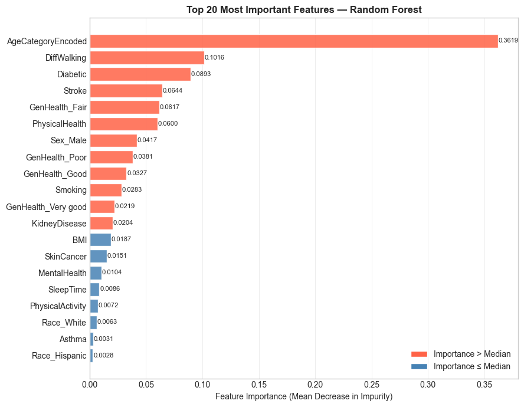

```
Top 10 most important features:
AgeCategoryEncoded    0.361930
DiffWalking           0.101573
Diabetic              0.089301
Stroke                0.064373
GenHealth_Fair        0.061688
PhysicalHealth        0.060031
Sex_Male              0.041734
GenHealth_Poor        0.038141
GenHealth_Good        0.032698
Smoking               0.028256
```

```python
############################################
# Random Forest Feature Importances Figure #
############################################

# Calculate feature importances, select top 20
importances = pd.Series(rf_best.feature_importances_, index=X.columns)
top20 = importances.sort_values(ascending=True).tail(20)

# Create horizontal bar chart for top 20 features
fig, ax = plt.subplots(figsize=(9, 7))
colors = ['tomato' if v > importances.median() else 'steelblue' for v in top20.values]
bars = ax.barh(top20.index, top20.values, color=colors, alpha=0.85, edgecolor='white')

# Update axes and labels
ax.set_xlabel('Feature Importance (Mean Decrease in Impurity)')
ax.set_title('Top 20 Most Important Features — Random Forest', fontweight='bold')
ax.grid(False)
ax.grid(axis='x', linewidth=0.5, alpha=0.5)
for bar in bars:
    ax.text(bar.get_width() + 0.0005, bar.get_y() + bar.get_height()/2, f'{bar.get_width():.4f}', va='center', fontsize=8)
plt.tight_layout()
legend_elements = [Patch(facecolor='tomato', edgecolor='white', label='Importance > Median'), Patch(facecolor='steelblue', edgecolor='white', label='Importance ≤ Median')]
ax.legend(handles=legend_elements, loc='lower right')
plt.show()

# Print top 10 most important features with their importance scores
print("\nTop 10 most important features:")
print(importances.sort_values(ascending=False).head(10).to_string())
```

`AgeCategoryEncoded` is the most important feature by far, which makes sense given the strong association between age and heart disease. `DiffWalking` and `Diabetic` also contribute significantly, indicating that mobility issues and diabetes are important risk factors for heart disease in this dataset.

Other than these top three factors, every feature highlighted in orange is above the median for importance. These factors have more of an impact on determining and predicting heart disease than the others. Thus, when predicting and identifying heart disease risks these factors are likely the most important to observe.

The fact that the model seems to determine that long-term health status factors are more important than other factors seems to suggest that short-term behavioral variables such as smoking are overshadowed by these long-term effects. This somewhat removes usefulness of the predictive model, as it has not determined any effective treatment/preventitive measures for heart disease. However, this is natural as if there were any easy fix to heart disease this would not be a widespread issue..

### 2) Coefficient Strengths (Logistic Regression)

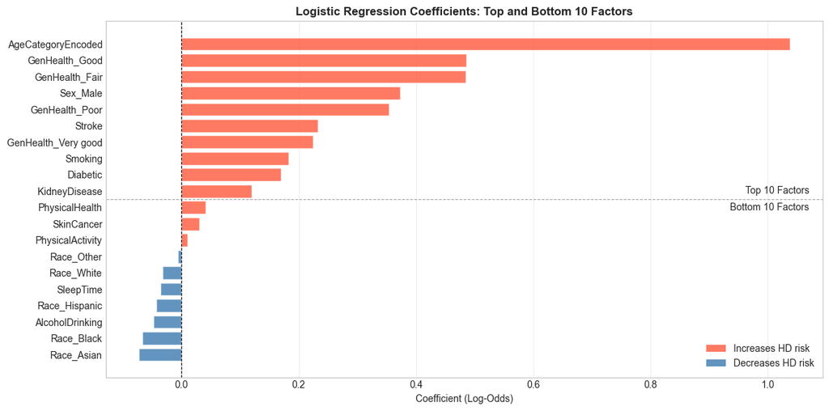

```python
##################################################
# Logistic Regression Coefficient Weights Figure #
##################################################

# Create df of features and their coefficients
coef_df = pd.DataFrame({'feature': X.columns, 'coefficient': lr_best.coef_[0]}).sort_values('coefficient', ascending=False)

# Top 10 positive and top 10 negative coefficients
top_pos = coef_df.head(10)
top_neg = coef_df.tail(10)
top_coef = pd.concat([top_pos, top_neg]).sort_values('coefficient')

# Setup horizontal bar chart for coefficients
fig, ax = plt.subplots()
colors = ['tomato' if c > 0 else 'steelblue' for c in top_coef['coefficient']]
bars = ax.barh(top_coef['feature'], top_coef['coefficient'], color=colors, alpha=0.85, edgecolor='white')

# Update axes and labels
ax.axvline(x=0, color='black', linewidth=0.8, linestyle='--')
ax.set_xlabel('Coefficient (Log-Odds)')
ax.set_title('Logistic Regression Coefficients: Top and Bottom 10 Factors', fontweight='bold')
ax.grid(False)
ax.grid(axis='x', linewidth=0.5, alpha=0.5)
# Line separating top and bottom 10 coefficients
ax.axhline(y=9.5, color='gray', linewidth=0.8, linestyle='--', alpha=0.7)
# Label the line to the right
ax.text(1.07, 9.7, 'Top 10 Factors', ha='right', va='bottom')
ax.text(1.07, 9.3, 'Bottom 10 Factors', ha='right', va='top')


# Legend
legend_elements = [Patch(facecolor='tomato', alpha=0.85, label='Increases HD risk'), Patch(facecolor='steelblue', alpha=0.85, label='Decreases HD risk')]
ax.legend(handles=legend_elements, loc='lower right')
plt.tight_layout()
plt.show()
```

The coefficient plot above reveals which features most strongly influence our **Logistic Regression** model's predictions, specifically the top and bottom 10. Features with positive coefficients (colored in orange) increase the predicted risk of heart disease, while features with negative coefficients (colored in blue) decrease it. **Age is by far the most influential predictor**, with a coefficient exceeding 1.0, its the largest in magnitude by a wide margin. Because we ordinally encoded `AgeCategory` (0 = 18–24, ..., 12 = 80+), this coefficient tells us that each step up in age group meaningfully raises the log-odds of heart disease, confirming what our EDA already showed. Among the other positive risk factors, `Stroke`, `Smoking`, `Diabetic`, and `KidneyDisease` all increase predicted risk. Interestingly, all levels of `GenHealth` appear as positive coefficients (even including "Very good") which is likely due to on-hot ecnoding dropping the reference category "Excellent", so every other health status is being compared *against* excellent health, meaning even "Very good" represents a relative increase in risk compared to the baseline. On the other side, `AlcoholDrinking`, `Race_Black`, and `Race_Asian` show negative coefficients, suggesting lower predicted risk. However, these should be causally interpreted as they likely reflect underlying demographic patterns in the CDC survey data rather than directly protecting against heart disease.

### 3) Confusion Matrices for RandomForest and Logistic Regression

Confusion matrix guide:

- Top-left (TN): correctly predicted "No Heart Disease"
- Top-right (FP): wrongly flagged as "Heart Disease"
- Bottom-left (FN): missed actual "Heart Disease" cases
- Bottom-right (TP): correctly detected "Heart Disease"

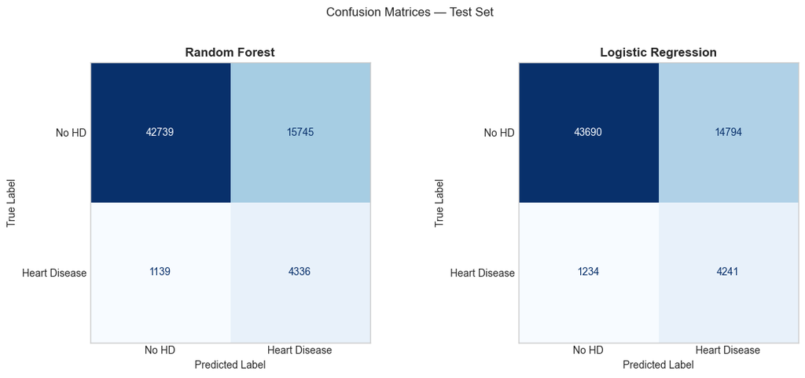

```python
###############################################################
# Confusion Matrices for RandomForest and Logistic Regression #
###############################################################

# Setup plots
fig, axes = plt.subplots(1, 2, figsize=(12, 5))

# Display plots
for ax, y_pred, title in zip(axes, [y_pred_rf, y_pred_lr], ['Random Forest', 'Logistic Regression']):
    cm = confusion_matrix(y_test, y_pred)
    disp = ConfusionMatrixDisplay(confusion_matrix=cm,display_labels=['No HD', 'Heart Disease'])
    disp.plot(ax=ax, colorbar=False, cmap='Blues')
    ax.set_title(title, fontweight='bold')
    ax.set_xlabel('Predicted Label')
    ax.set_ylabel('True Label')
    ax.grid(False)

# Update layout
plt.suptitle('Confusion Matrices — Test Set', y=1.02)
plt.tight_layout()
plt.show()
```

As seen in the bottom left corner (False Negatives), the **Random Forest** model misses fewer actual heart disease cases (**1139**) compared to **Logistic Regression** (**1234**). This means that **Random Forest** is better at catching true positives, which is crucial in medical contexts where missing a real case can have serious consequences. However, both models produce a significant number of False Positives (top right corner), with **Random Forest** having slightly more than **Logistic Regression**. This means that many patients may be flagged for further testing unnecessarily. However, positive detection is more important in this context as there are more consequences to not identifying a true case of heart disease. Overall, the confusion matrices confirm that while both models have similar precision, the Random Forest model has a higher recall, making it more effective at identifying true heart disease cases.

## Model Selection

After training and evaluating both models, we choose the "better" one based on test-set metrics. Since our dataset is highly imbalanced and we care mostly about correctly identifying heart diease patients (recall), we prioritize recall on the positive class (catching real heart disease cases).

```python
############################
# Summary comparison table #
############################

# Generate summary table
summary = pd.DataFrame({
    'Model': ['Random Forest', 'Logistic Regression'],
    'Recall (HD)': [
        round(recall_score(y_test, y_pred_rf, pos_label=1), 4),
        round(recall_score(y_test, y_pred_lr, pos_label=1), 4)
    ],
    'Precision (HD)': [
        round(precision_score(y_test, y_pred_rf, pos_label=1), 4),
        round(precision_score(y_test, y_pred_lr, pos_label=1), 4)
    ],
    'F1 (HD)': [
        round(f1_score(y_test, y_pred_rf, pos_label=1), 4),
        round(f1_score(y_test, y_pred_lr, pos_label=1), 4)
    ]
})
display(summary)
```

|  | Model | Recall (HD) | Precision (HD) | F1 (HD) |
| --- | --- | --- | --- | --- |
| 0 | Random Forest | 0.7920 | 0.2159 | 0.3393 |
| 1 | Logistic Regression | 0.7746 | 0.2228 | 0.3461 |

**Best Model**: Random Forest Classifier

**Precision** is similar in both models, however the **Recall** score of **Random Forest** is better than **Logistic Regression**. The negligible difference of 0.0069 in **precision** is outweighed by the increase in **Recall** score. In a medical context, recall is often more important than precision because we want to catch as many true cases as possible, even if it means some false positives. Therefore, the **Random Forest** model is better at identifying actual heart disease cases, which is crucial for early detection and treatment.

Additionally, **Random Forest** allows for us to examine the feature importances and understand the contribution of each feature to the model's predictions. Determining what factors may lead to, and or point to heart disease is arguably more important than model accuracy, as most people/end users will not make decisions based on all of the same data points as are in this data set.

# Insights and Conclusions

### What We Found

Through exploratory data analysis, statistical hypothesis testing, and machine learning, we investigated the most significant predictors of heart disease and trained a model capable of predicting it from survey-level health data. Here is what the data told us:

### Key Findings from EDA

- **Age is the strongest demographic predictor.** The Chi-squared test confirmed a statistically significant association between age category and heart disease (p < 0.05), and the grouped bar chart demonstrated that prevalence rises for individuals aged 60 and older.
- **Smoking has a stronger impact on heart disease than alcohol consumption.** Our ANOVA and Tukey HSD test showed significant pairwise differences between all three lifestyle groups (smokers only, drinkers only, both). The combination of smoking and drinking was not substantially worse than smoking alone, surprisingly suggesting smoking as the dominant risk factor among the two.
- **Men are significantly more likely to be diagnosed with heart disease than women.** Confirmed by a Chi-squared test.

### Key Findings from Machine Learning

- **Random Forest outperformed Logistic Regression** in recall. The Random Forest model was better at identifying true heart disease cases, which is crucial for early detection and treatment. Also the Random Forest model allows us to examine feature importances, which is valuable for understanding the underlying risk factors.
- **Class imbalance (approx. 91% negative, 9% positive) was a real challenge**, and using `class_weight='balanced'` in both models was essential. Without this adjustment, a naive model could "cheat" by always predicting No Heart Disease and still appear 91% accurate while being clinically useless.
- **The most influential predictors identified by the Random Forest were:** age (`AgeCategoryEncoded`), difficulty walking (`diffWalking`), and diabetes (`Diabetes`)

## Limitations

- **Survey data introduces self-reporting bias.** People may under-report behaviors like smoking or alcohol consumption, and may not accurately assess their own health.
- **The dataset is cross-sectional.** We observe features and outcomes at a single point in time.
- **Demographic skew:** The BRFSS dataset over-represents certain racial and age groups, which may affect how well the model generalizes to underrepresented populations.

## Broader Implications

Despite limitations, this analysis demonstrates that **widely available, survey-level health data can meaningfully predict heart disease risk**. The use of a model like this in a primary care setting could help flag high-risk individuals for earlier screening before symptoms occur. The most actionable insight is that age, physical ability such as difficulty walking, as well as the presence of diabetes are the clearest metrics for identifying at-risk patients.

Based on our model, **long term health factors** like age, physical ability, and diabetes status are **more influential** than **short-term behaviors** like smoking or drinking. This suggests that while lifestyle changes are important, they may not be sufficient to significantly reduce heart disease risk on their own. Instead, **regular monitoring of long-term health indicators and early interventions for conditions like diabetes may be more effective strategies for preventing heart disease**.